# Analyzing Individual BGG Users

Phil Henrickson

2022-01-02

# **AgitatedString’s** BoardGameGeek Collection

This notebook contains a set of analyses for the selected user’s boardgamegeek collection. The bulk of the analysis is focused on building a user-specific predictive model to predict the games that AgitatedString is likely to own. This enables to ask questions like, based on the games the user currently owns, what games are a good fit for their collection? What upcoming games are they likely to purchase?

This analysis is based on data from BoardGameGeek that was last updated on **2021-12-20.**

# 1 Collection Overview

We can look at a basic description of the number of games that the user owns, has rated, has previously owned, etc.

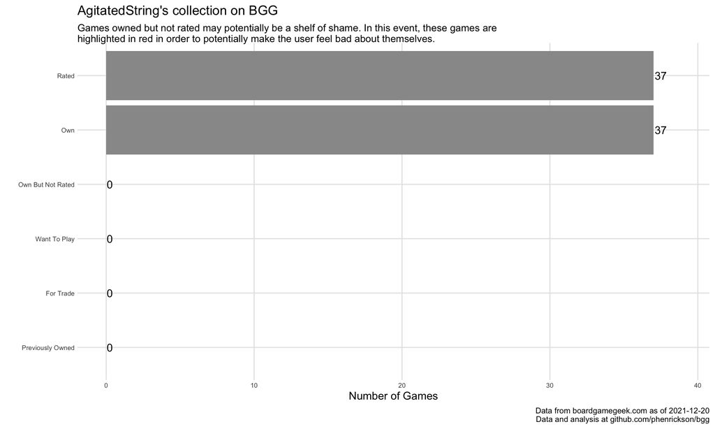

What years has the user owned/rated games from? While we can’t see when a user added or removed a game from their collection, we can look at their collection by the years in which their games were published.

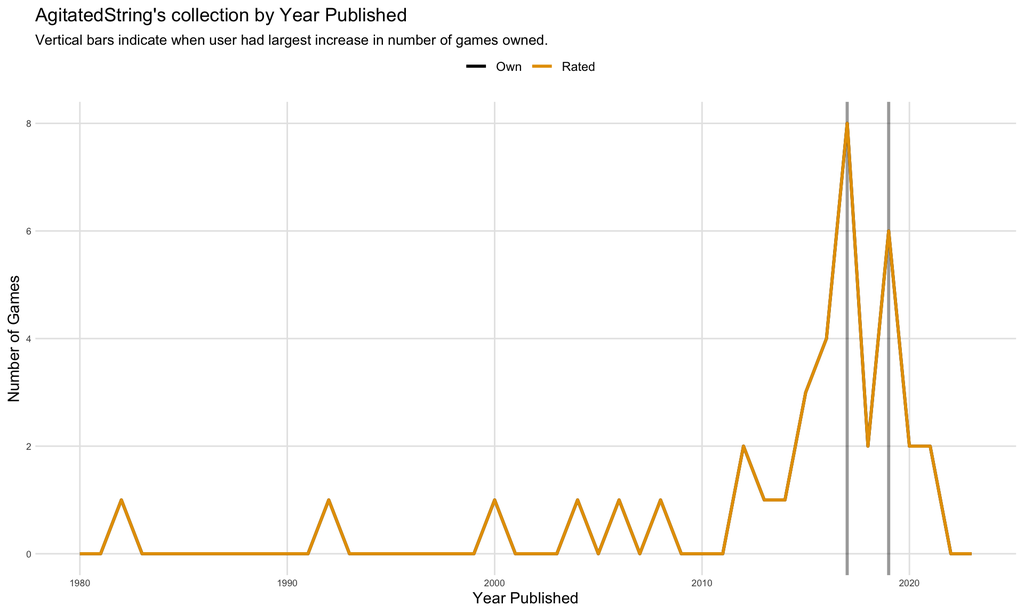

## 1.1 What types of games does AgitatedString own?

We can look at the most frequent types of categories, mechanics, designers, and artists that appear in a user’s collection.

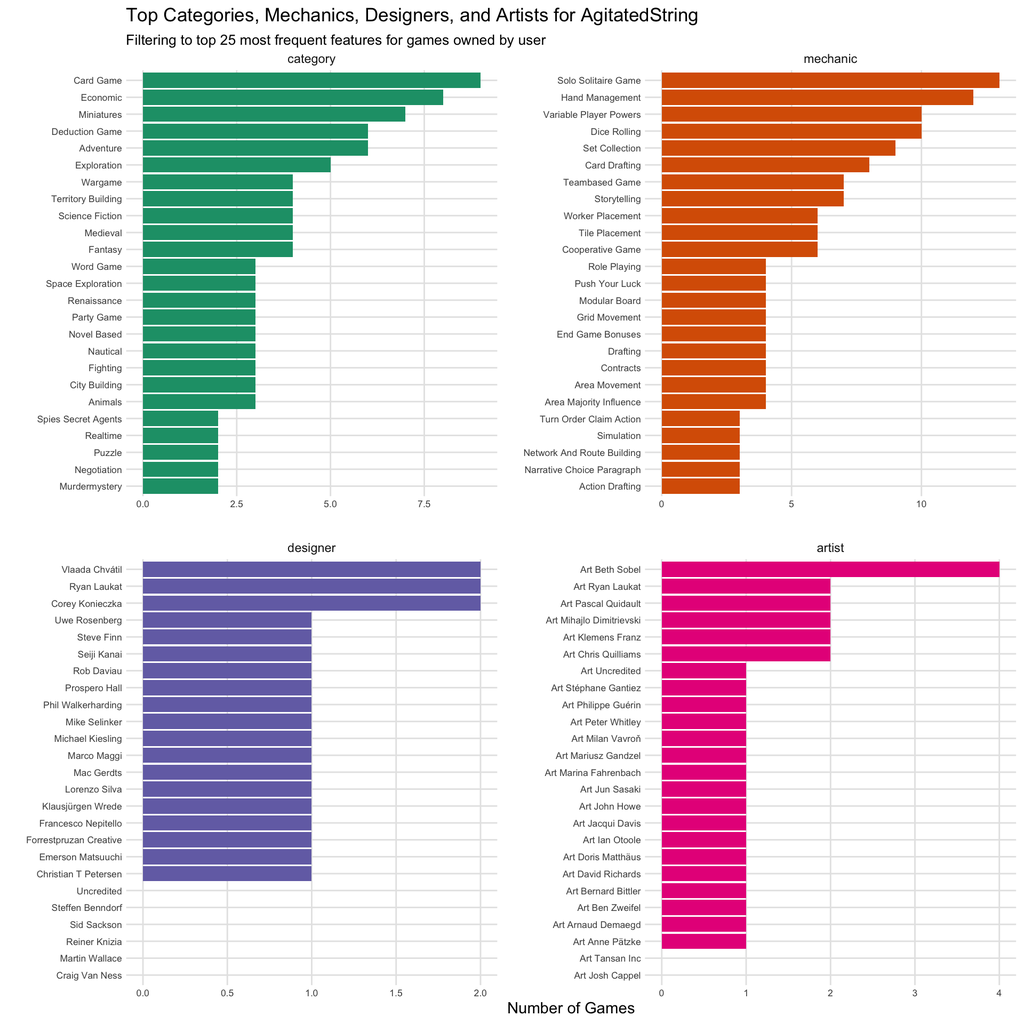

# 2 Modeling **AgitatedString’s** Collection

| username | dataset | period | games_owned | games_rated | games_played |
| --- | --- | --- | --- | --- | --- |
| AgitatedString | training | published before 2020 | 33 | 33 | 33 |
| AgitatedString | test | published 2020 or later | 4 | 4 | 4 |

There are two main (binary) outcomes we will be modeling for the user.

The first, **own** refers to whether the user currently lists a game as owned in their collection. The second, **played** refers to whether the user currently owns, has rated, or previously owned a game. This means the latter will generally have a larger list of games, but may still be a useful category to examine for people who play lots of games without necessarily owning them.

We will train predictive models to learn the probability that the user will own or play individual games based on their features.

## 2.1 Coefficients for AgitatedString

We can examine coefficients from the trained modes, which are penalized logistic regressions fit to our two main outcomes. Positive values indicate that a feature increases a user’s probabilility of owning/rating a game, while negative values indicate a feature decreases the probability.

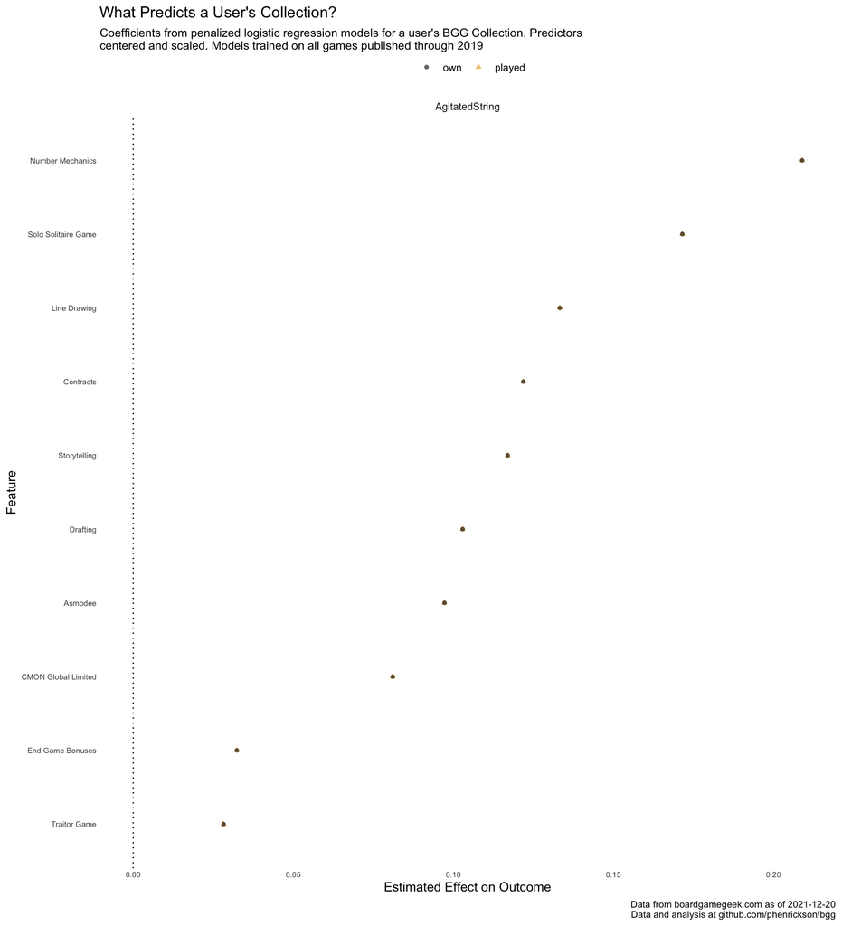

## 2.2 Visualizing Predictors for AgitatedString’s Collection

Why did the model identify these features? We can make density plots of the important features for predicting whether the user owned a game. Blue indicates the density for games owned by the user, while grey indicates the density for games not owned by the user.

[figure not shown]

Binary predictors can be difficult to see with this visualization, so we can also directly examine the percentage of games in a user’s collection with a predictor vs the percentage of all games with that predictor.

| username | Feature | % of Games with Feature In_Collection | % of Games with Feature All_Games | Ratio |
| --- | --- | --- | --- | --- |
| AgitatedString | Line Drawing | 9.1% | 0.7% | 12.9 |
| AgitatedString | Contracts | 12.1% | 1.0% | 12.1 |
| AgitatedString | Drafting | 12.1% | 1.0% | 12.0 |
| AgitatedString | CMON Global Limited | 9.1% | 0.8% | 11.4 |
| AgitatedString | End Game Bonuses | 12.1% | 1.3% | 9.6 |
| AgitatedString | Traitor Game | 6.1% | 0.7% | 9.2 |
| AgitatedString | Storytelling | 15.2% | 2.2% | 7.0 |
| AgitatedString | Renegade Game Studios | 6.1% | 0.9% | 6.9 |
| AgitatedString | Solo Solitaire Game | 33.3% | 5.8% | 5.7 |
| AgitatedString | Word Game | 9.1% | 1.7% | 5.2 |
| AgitatedString | Asmodee | 24.2% | 5.3% | 4.5 |
| AgitatedString | Teambased Game | 21.2% | 6.3% | 3.4 |
| AgitatedString | City Building | 9.1% | 4.3% | 2.1 |
| AgitatedString | Medieval | 12.1% | 6.3% | 1.9 |
| AgitatedString | Puzzle | 6.1% | 3.4% | 1.8 |
| AgitatedString | Negotiation | 6.1% | 3.6% | 1.7 |
| AgitatedString | Realtime | 6.1% | 4.2% | 1.5 |
| AgitatedString | Trains | 3.0% | 2.2% | 1.4 |
| AgitatedString | Party Game | 9.1% | 8.5% | 1.1 |
| AgitatedString | Horror | 3.0% | 4.0% | 0.8 |
| AgitatedString | Trivia | 0.0% | 1.8% | 0.0 |
| AgitatedString | Racing | 0.0% | 2.8% | 0.0 |
| AgitatedString | Action Dexterity | 0.0% | 4.8% | 0.0 |
| AgitatedString | Mafia | 0.0% | 0.7% | 0.0 |
| AgitatedString | Prehistoric | 0.0% | 1.0% | 0.0 |

# 3 Assess Model’s Performance on Training Set

Before predicting games in upcoming years, we can examine how well the model did and what games it liked in the training set. In this case, we used resampling techniques (cross validation) to ensure that the model had not seen a game before making its predictions.

## 3.1 Separation Plot

An easy way to examine the performance of classification model is to view a separation plot. We plot the predicted probabilities from the model for every game (from resampling) from lowest to highest. We then overlay a blue line for any game that the user does own. A good classifier is one that is able to *separate* the blue (games owned by the user) from the white (games not owned by the user), with most of the blue occurring at the highest probabilities (right side of the chart).

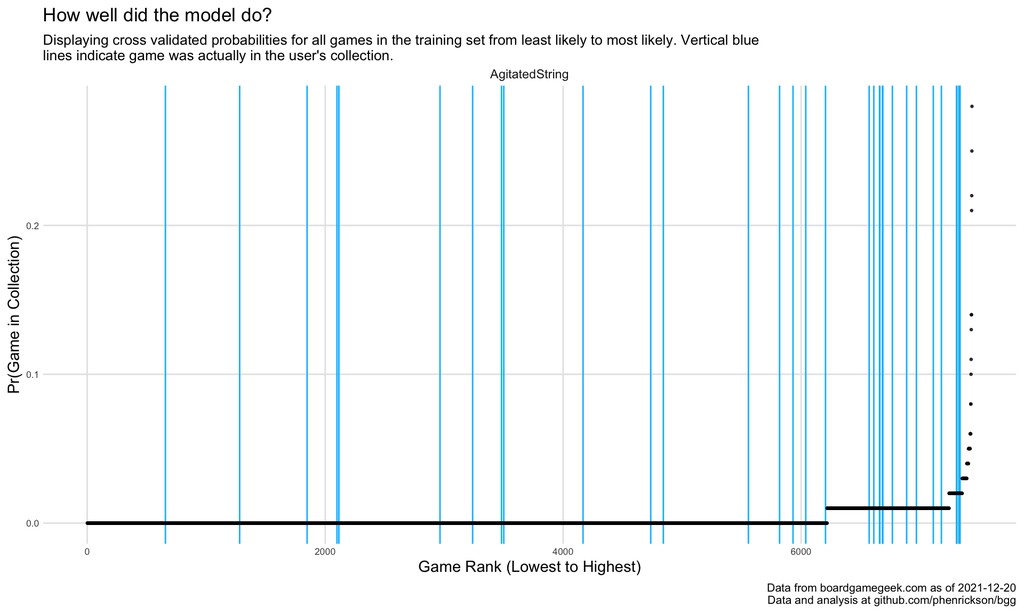

## 3.2 Top Games for **AgitatedString** from Training Set

We can display this information in table form, displaying the 100 games with the highest probability of ownership, adding a blue line when the user does own the game.

| username | yearpublished | game_id | name | pred_played | pred_own | actual_played | actual_own |
| --- | --- | --- | --- | --- | --- | --- | --- |
| AgitatedString | 2017 | 174430 | Gloomhaven | 0.28 | 0.28 | 0 | 0 |
| AgitatedString | 2018 | 205896 | Rising Sun | 0.25 | 0.25 | 0 | 0 |
| AgitatedString | 2019 | 283863 | The Magnificent | 0.22 | 0.22 | 0 | 0 |
| AgitatedString | 2019 | 276025 | Maracaibo | 0.21 | 0.21 | 0 | 0 |
| AgitatedString | 2018 | 245654 | Railroad Ink: Deep Blue Edition | 0.14 | 0.14 | 0 | 0 |
| AgitatedString | 2017 | 188920 | This War of Mine: The Board Game | 0.14 | 0.14 | 0 | 0 |
| AgitatedString | 2018 | 244711 | Newton | 0.13 | 0.13 | 0 | 0 |
| AgitatedString | 2015 | 171273 | FUSE | 0.11 | 0.11 | 0 | 0 |
| AgitatedString | 2019 | 283294 | Yukon Airways | 0.10 | 0.10 | 0 | 0 |
| AgitatedString | 2016 | 171131 | Captain Sonar | 0.08 | 0.08 | 0 | 0 |
| AgitatedString | 2019 | 260710 | Amul | 0.08 | 0.08 | 0 | 0 |
| AgitatedString | 2016 | 199269 | 1572: The Lost Expedition | 0.06 | 0.06 | 0 | 0 |
| AgitatedString | 2019 | 283393 | Aquatica | 0.06 | 0.06 | 0 | 0 |
| AgitatedString | 2019 | 251412 | On Tour | 0.06 | 0.06 | 0 | 0 |
| AgitatedString | 1998 | 891 | Cranium | 0.06 | 0.06 | 0 | 0 |
| AgitatedString | 2016 | 198454 | When I Dream | 0.06 | 0.06 | 0 | 0 |
| AgitatedString | 2014 | 154203 | Imperial Settlers | 0.05 | 0.05 | 0 | 0 |
| AgitatedString | 2015 | 170216 | Blood Rage | 0.05 | 0.05 | 0 | 0 |
| AgitatedString | 2018 | 259809 | Sonar Family | 0.05 | 0.05 | 0 | 0 |
| AgitatedString | 2019 | 270970 | Century: A New World | 0.05 | 0.05 | 0 | 0 |
| AgitatedString | 2009 | 39683 | At the Gates of Loyang | 0.05 | 0.05 | 0 | 0 |
| AgitatedString | 2015 | 182874 | Grand Austria Hotel | 0.05 | 0.05 | 0 | 0 |
| AgitatedString | 2019 | 251247 | Barrage | 0.05 | 0.05 | 0 | 0 |
| AgitatedString | 2019 | 264220 | Tainted Grail: The Fall of Avalon | 0.05 | 0.05 | 0 | 0 |
| AgitatedString | 2009 | 55158 | Luna Llena: Full Moon | 0.05 | 0.05 | 0 | 0 |
| AgitatedString | 2001 | 6420 | Cranium Cadoo | 0.05 | 0.05 | 0 | 0 |
| AgitatedString | 2014 | 165628 | HINT | 0.05 | 0.05 | 0 | 0 |
| AgitatedString | 2019 | 271324 | It's a Wonderful World | 0.05 | 0.05 | 0 | 0 |
| AgitatedString | 2018 | 242639 | Treasure Island | 0.05 | 0.05 | 0 | 0 |
| AgitatedString | 2016 | 167791 | Terraforming Mars | 0.05 | 0.05 | 0 | 0 |

[output cut: 70 more lines]

We can also more formally assess how well the model did in resampling by looking at the area under the receiver operating characteristic. A perfect model would receive a score of 1, while a model that cannot predict the outcome will default to a score of 0.5. The extent to which something is a *good* score depends on the setting, but generally anything in the .8 to .9 range is very good while the .7 to .8 range is perfectly acceptable.

| username | outcome_type | .metric | .estimator | .estimate |
| --- | --- | --- | --- | --- |
| AgitatedString | own | roc_auc | binary | 0.719 |
| AgitatedString | played | roc_auc | binary | 0.719 |

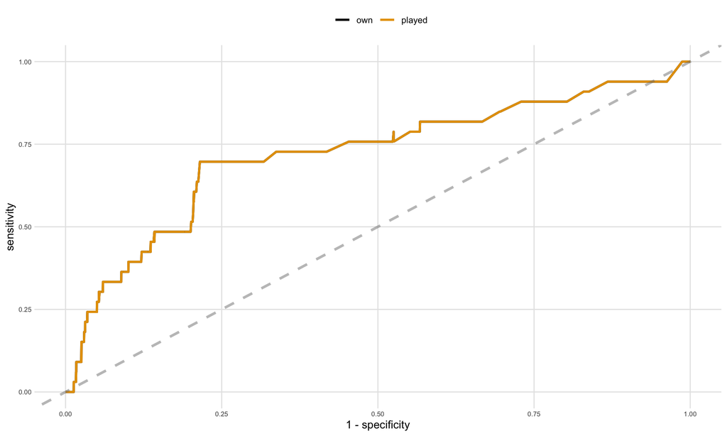

Another way to think about the model performance is to view its lift, or its ability to detect the positive outcomes over that of a null model. High lift indicates the model can much more quickly find all of the positive outcomes (in this case, games owned or played by the user), while a model with no lift is no better than random guessing.

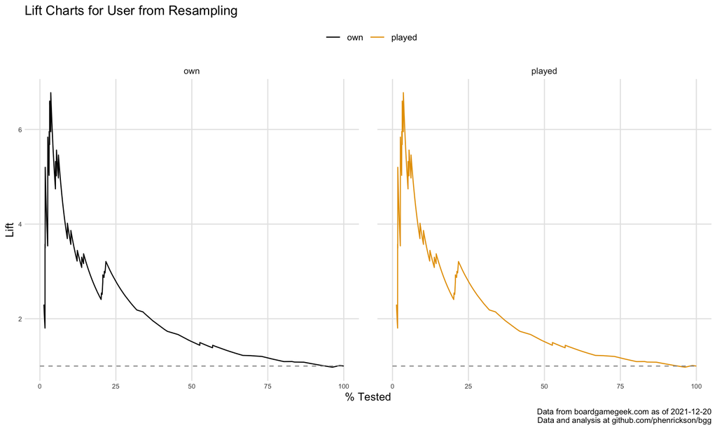

## 3.3 Most and Least Likely Games

What games does the model think AgitatedString is **most likely to own** that are **not** in their collection?

| username | yearpublished | game_id | name | pred_own | actual_own |
| --- | --- | --- | --- | --- | --- |
| AgitatedString | 2017 | 174430 | Gloomhaven | 0.28 | 0 |
| AgitatedString | 2018 | 205896 | Rising Sun | 0.25 | 0 |
| AgitatedString | 2019 | 283863 | The Magnificent | 0.22 | 0 |
| AgitatedString | 2019 | 276025 | Maracaibo | 0.21 | 0 |
| AgitatedString | 2018 | 245654 | Railroad Ink: Deep Blue Edition | 0.14 | 0 |

What games does the model think AgitatedString is **least likely to own** that **are** in their collection?

| username | yearpublished | game_id | name | pred_own | actual_own |
| --- | --- | --- | --- | --- | --- |
| AgitatedString | 2017 | 175324 | Fog of Love | 0 | 1 |
| AgitatedString | 2012 | 115746 | War of the Ring: Second Edition | 0 | 1 |
| AgitatedString | 2016 | 187645 | Star Wars: Rebellion | 0 | 1 |
| AgitatedString | 2016 | 194607 | Mystic Vale | 0 | 1 |
| AgitatedString | 2017 | 219513 | Bärenpark | 0 | 1 |

## 3.4 Top Games by Year

Top 25 games most likely to be owned by the user in each year, highlighting in blue the games that the user has owned/played.

| rank | 2011 | 2012 | 2013 | 2014 | 2015 | 2016 | 2017 | 2018 | 2019 |
| --- | --- | --- | --- | --- | --- | --- | --- | --- | --- |
| 1 | Takenoko | Mice and Mystics | Room 25 | Imperial Settlers | FUSE | Captain Sonar | Gloomhaven | Rising Sun | The Magnificent |
| 2 | Mage Knight Board Game | Keyflower | Sushi Go! | HINT | Blood Rage | 1572: The Lost Expedition | This War of Mine: The Board Game | Railroad Ink: Deep Blue Edition | Maracaibo |
| 3 | Dixit: Odyssey | Archipelago | Gravwell: Escape from the 9th Dimension | Deception: Murder in Hong Kong | Grand Austria Hotel | When I Dream | Sagrada | Newton | Yukon Airways |
| 4 | A Few Acres of Snow | Lords of Waterdeep | Rory's Story Cubes: Prehistoria | La Granja | Argonauts | Terraforming Mars | The 7th Continent | Sonar Family | Amul |
| 5 | Sekigahara: The Unification of Japan | Agents of SMERSH | Funemployed | Ultimate Werewolf | The Voyages of Marco Polo | Black Orchestra | Richard the Lionheart | Treasure Island | Aquatica |
| 6 | Ascension: Return of the Fallen | Il Vecchio | Forbidden Desert | Arcadia Quest | Dojo Kun | Hit Z Road | Raging Bulls | Realm of Sand | On Tour |
| 7 | Field Commander: Napoleon | Lucky Numbers | Lewis & Clark: The Expedition | Doodle Quest | The Pursuit of Happiness | Dead of Winter: The Long Night | Yamataï | Lords of Hellas | Century: A New World |
| 8 | Ventura | A Fake Artist Goes to New York | Dungeon Twister: The Card Game | Stay Away! | Kingdom Death: Monster | Star Trek: The Dice Game | Bunny Kingdom | Everdell | Barrage |
| 9 | The Castles of Burgundy | Saint Malo | Navajo Wars | Doodle City | Raiders of the North Sea | Inis | Photosynthesis | Gizmos | Tainted Grail: The Fall of Avalon |
| 10 | Principato | Escape: The Curse of the Temple | The Hunters: German U-Boats at War, 1939-43 | Praetor | The Bloody Inn | Aventuria: Adventure Card Game | Escape the Dark Castle | The Grizzled: Armistice Edition | It's a Wonderful World |
| 11 | Village | Mage Wars Arena | Pizza Party | Dead of Winter: A Crossroads Game | Aye, Dark Overlord! The Green Box | Behind the Throne | Gekido: Bot Battles | Cosmic Run: Regeneration | Era: Medieval Age |
| 12 | Discworld: Ankh-Morpork | Nuklear Winter '68 | Cruel Necessity: The English Civil Wars 1640-1653 | Akrotiri | Between Two Cities | Islebound | Pocket Mars | Space Park | Last Bastion |
| 13 | Pastiche | Urbion | Maquis | Saboteur: The Duel | Grimslingers | Kepler-3042 | Clans of Caledonia | Vengeance | Tiny Towns |
| 14 | Ascension: Storm of Souls | Thunderbolt Apache Leader | Venetia | Fields of Arle | Viticulture Essential Edition | Sushi Go Party! | Magic Maze | Sprawlopolis | Ragusa |
| 15 | Tragedy Looper | In Magnificent Style: Pickett's Charge at Gettysburg | Pathfinder Adventure Card Game: Rise of the Runelords – Base Set | Onirim (Second Edition) | Super Dungeon Explore: Forgotten King | Raise Your Goblets | Kokoro: Avenue of the Kodama | Betrayal Legacy | Chai |
| 16 | Elder Sign | PIX | Legacy: The Testament of Duke de Crecy | Hapsburg Eclipse | Tulip Bubble | Avenue | Unlock!: Escape Adventures – Squeek & Sausage | Dice Hospital | PARKS |
| 17 | Timeline: Events | Suburbia | Berserk: War of the Realms | Elevenses for One | Tiny Epic Galaxies | The Networks | Unlock!: Escape Adventures – Temple of Ra | Chronicles of Crime | Chocolate Factory |
| 18 | Eselsbrücke | Serenissima (Second Edition) | Prosperity | Sons of Anarchy: Men of Mayhem | Raptor | Silent Victory: U.S. Submarines in the Pacific, 1941-45 | King of the Dice | Holding On: The Troubled Life of Billy Kerr | Circadians: First Light |
| 19 | Telestrations: 12 Player Party Pack | Divided Republic | Tash-Kalar: Arena of Legends | Deus | Bottom of the 9th | Mini Rogue: A 9-Card Print-and-Play Game | Runewars Miniatures Game | Underwater Cities | The Isle of Cats |
| 20 | Rory's Story Cubes: Voyages | Spartacus: A Game of Blood and Treachery | Firefly: The Game | Fire in the Lake | Agent Decker | 13 Days: The Cuban Missile Crisis | Aristeia! | Century: Eastern Wonders | Call to Adventure |
| 21 | Dark Moon | Andean Abyss | Castle Dice | Five Tribes | Deep Space D-6 | Smash Up: Cease and Desist | LYNGK | That's Pretty Clever! | Herbaceous Sprouts |
| 22 | Letters from Whitechapel | Wiz-War (Eighth Edition) | Kashgar: Merchants of the Silk Road | Roll Through the Ages: The Iron Age | Coffee Roaster | Nautilion | One Deck Dungeon: Forest of Shadows | Gingerbread House | Clank!: Legacy – Acquisitions Incorporated |
| 23 | Mundus Novus | Seasons | Canalis | Abyss | The Maiden in the Forest | Mr. Cabbagehead's Garden | Colonial Twilight: The French-Algerian War, 1954-62 | Big Trouble in Little China: The Game | Dungeon Academy |
| 24 | Skull | Fantastiqa: The Rucksack Edition | The Hobbit: An Unexpected Journey | Black Fleet | Brick Party | Comanchería: The Rise and Fall of the Comanche Empire | Circle the Wagons | Once Upon a Castle | The King's Dilemma |
| 25 | Panic Station | Smash Up | Corto | DungeonQuest Revised Edition | Rolling America | Four Against Darkness | A4 Quest | Pax Emancipation | God of War: The Card Game |

## 3.5 Interactive Predictions from Resampling

Interactive table for predictions from resampling.

|  | username | yearpublished | rank | game_id | name | pred_played | pred_own | actual_played | actual_own |
| --- | --- | --- | --- | --- | --- | --- | --- | --- | --- |
| 1 | AgitatedString | 1900 | 921 | 45 | Perudo | 0.01 | 0.01 | 0 | 0 |
| 2 | AgitatedString | 1900 | 1232 | 5546 | Marbles | 0 | 0 | 0 | 0 |
| 3 | AgitatedString | 1900 | 1235 | 11901 | Tic-Tac-Toe | 0 | 0 | 0 | 0 |
| 4 | AgitatedString | 1900 | 1276 | 188 | Go | 0 | 0 | 0 | 0 |
| 5 | AgitatedString | 1900 | 1380 | 171 | Chess | 0 | 0 | 0 | 0 |
| 6 | AgitatedString | 1900 | 1391 | 2065 | Shogi | 0 | 0 | 0 | 0 |
| 7 | AgitatedString | 1900 | 1393 | 2393 | Xiangqi | 0 | 0 | 0 | 0 |
| 8 | AgitatedString | 1900 | 1611 | 26952 | International Checkers | 0 | 0 | 0 | 0 |
| 9 | AgitatedString | 1900 | 1648 | 1602 | The Royal Game of Ur | 0 | 0 | 0 | 0 |
| 10 | AgitatedString | 1900 | 1649 | 2083 | Checkers | 0 | 0 | 0 | 0 |

[output cut: 7426 more lines]

# 4 Validating the Model on 2020

How well did a model trained on a user’s collection through 2019 perform in predicting games for the user from 2020?

| username | outcome_type | yearpublished | .metric | .estimator | .estimate |
| --- | --- | --- | --- | --- | --- |
| AgitatedString | own | 2020 | roc_auc | binary | 0.914 |
| AgitatedString | played | 2020 | roc_auc | binary | 0.914 |

Table of top 25 games from 2020, highlighting games that the user owns.

| username | yearpublished | game_id | name | pred_own | pred_played | actual_own | actual_played |
| --- | --- | --- | --- | --- | --- | --- | --- |
| AgitatedString | 2020 | 184267 | On Mars | 0.20 | 0.20 | 0 | 0 |
| AgitatedString | 2020 | 301880 | Raiders of Scythia | 0.07 | 0.07 | 0 | 0 |
| AgitatedString | 2020 | 300322 | Hallertau | 0.06 | 0.06 | 0 | 0 |
| AgitatedString | 2020 | 262274 | D6: Dungeons, Dudes, Dames, Danger, Dice and Dragons! | 0.05 | 0.05 | 0 | 0 |
| AgitatedString | 2020 | 267009 | Rome & Roll | 0.05 | 0.05 | 0 | 0 |
| AgitatedString | 2020 | 266188 | Seven Bridges | 0.04 | 0.04 | 0 | 0 |
| AgitatedString | 2020 | 284742 | Honey Buzz | 0.04 | 0.04 | 0 | 0 |
| AgitatedString | 2020 | 307844 | Atheneum: Mystic Library | 0.04 | 0.04 | 0 | 0 |
| AgitatedString | 2020 | 274841 | Cóatl | 0.03 | 0.03 | 0 | 0 |
| AgitatedString | 2020 | 281075 | Welcome to New Las Vegas | 0.03 | 0.03 | 0 | 0 |
| AgitatedString | 2020 | 291457 | Gloomhaven: Jaws of the Lion | 0.03 | 0.03 | 0 | 0 |
| AgitatedString | 2020 | 297030 | Tekhenu: Obelisk of the Sun | 0.03 | 0.03 | 0 | 0 |
| AgitatedString | 2020 | 306040 | Merv: The Heart of the Silk Road | 0.03 | 0.03 | 0 | 0 |
| AgitatedString | 2020 | 306481 | Tawantinsuyu: The Inca Empire | 0.03 | 0.03 | 0 | 0 |
| AgitatedString | 2020 | 324246 | Journey to the Center of the Earth | 0.03 | 0.03 | 0 | 0 |
| AgitatedString | 2020 | 252153 | Tang Garden | 0.02 | 0.02 | 0 | 0 |
| AgitatedString | 2020 | 266993 | Call to Adventure: The Stormlight Archive | 0.02 | 0.02 | 0 | 0 |
| AgitatedString | 2020 | 270143 | Kōhaku | 0.02 | 0.02 | 0 | 0 |
| AgitatedString | 2020 | 280794 | Etherfields | 0.02 | 0.02 | 0 | 0 |
| AgitatedString | 2020 | 289939 | Goblin Teeth | 0.02 | 0.02 | 0 | 0 |
| AgitatedString | 2020 | 291508 | Tiny Epic Dinosaurs | 0.02 | 0.02 | 0 | 0 |
| AgitatedString | 2020 | 292333 | Cowboys II: Cowboys & Indians Edition | 0.02 | 0.02 | 0 | 0 |
| AgitatedString | 2020 | 298047 | Marvel United | 0.02 | 0.02 | 0 | 0 |
| AgitatedString | 2020 | 298130 | Amalfi | 0.02 | 0.02 | 0 | 0 |
| AgitatedString | 2020 | 299179 | Chancellorsville 1863 | 0.02 | 0.02 | 0 | 0 |

# 5 Predicting Upcoming Games (2020 and On) for **AgitatedString**

Examine the top games for the test set.

| username | yearpublished | game_id | name | rank | own | played |
| --- | --- | --- | --- | --- | --- | --- |
| AgitatedString | 2020 | 184267 | On Mars | 1 | 0.20 | 0.20 |
| AgitatedString | 2020 | 301880 | Raiders of Scythia | 2 | 0.07 | 0.07 |
| AgitatedString | 2020 | 300322 | Hallertau | 3 | 0.06 | 0.06 |
| AgitatedString | 2020 | 267009 | Rome & Roll | 4 | 0.05 | 0.05 |
| AgitatedString | 2020 | 262274 | D6: Dungeons, Dudes, Dames, Danger, Dice and Dragons! | 5 | 0.05 | 0.05 |
| AgitatedString | 2020 | 284742 | Honey Buzz | 6 | 0.04 | 0.04 |
| AgitatedString | 2020 | 266188 | Seven Bridges | 7 | 0.04 | 0.04 |
| AgitatedString | 2020 | 307844 | Atheneum: Mystic Library | 8 | 0.04 | 0.04 |
| AgitatedString | 2020 | 297030 | Tekhenu: Obelisk of the Sun | 9 | 0.03 | 0.03 |
| AgitatedString | 2020 | 274841 | Cóatl | 10 | 0.03 | 0.03 |
| AgitatedString | 2020 | 281075 | Welcome to New Las Vegas | 11 | 0.03 | 0.03 |
| AgitatedString | 2020 | 306481 | Tawantinsuyu: The Inca Empire | 12 | 0.03 | 0.03 |
| AgitatedString | 2020 | 306040 | Merv: The Heart of the Silk Road | 13 | 0.03 | 0.03 |
| AgitatedString | 2020 | 324246 | Journey to the Center of the Earth | 14 | 0.03 | 0.03 |
| AgitatedString | 2020 | 291457 | Gloomhaven: Jaws of the Lion | 15 | 0.03 | 0.03 |
| AgitatedString | 2020 | 304434 | Victim: The Cursed Forest | 16 | 0.02 | 0.02 |
| AgitatedString | 2020 | 319223 | Sleeping Gods: Primeval Peril | 17 | 0.02 | 0.02 |
| AgitatedString | 2020 | 302809 | Betrayal at Mystery Mansion | 18 | 0.02 | 0.02 |
| AgitatedString | 2020 | 299179 | Chancellorsville 1863 | 19 | 0.02 | 0.02 |
| AgitatedString | 2020 | 302723 | Forgotten Waters | 20 | 0.02 | 0.02 |
| AgitatedString | 2020 | 316554 | Dune: Imperium | 21 | 0.02 | 0.02 |
| AgitatedString | 2020 | 266993 | Call to Adventure: The Stormlight Archive | 22 | 0.02 | 0.02 |
| AgitatedString | 2020 | 321713 | Quest Calendar: The Dragon Staff of Maladoria | 23 | 0.02 | 0.02 |
| AgitatedString | 2020 | 316377 | 7 Wonders (Second Edition) | 24 | 0.02 | 0.02 |
| AgitatedString | 2020 | 270143 | Kōhaku | 25 | 0.02 | 0.02 |
| AgitatedString | 2021 | 249277 | Brazil: Imperial | 1 | 0.11 | 0.11 |
| AgitatedString | 2021 | 252752 | Genotype: A Mendelian Genetics Game | 2 | 0.09 | 0.09 |
| AgitatedString | 2021 | 319999 | Dungeon Decorators | 3 | 0.06 | 0.06 |
| AgitatedString | 2021 | 306881 | Railroad Ink Challenge: Lush Green Edition | 4 | 0.04 | 0.04 |
| AgitatedString | 2021 | 306882 | Railroad Ink Challenge: Shining Yellow Edition | 5 | 0.04 | 0.04 |
| AgitatedString | 2021 | 273330 | Bloodborne: The Board Game | 6 | 0.04 | 0.04 |
| AgitatedString | 2021 | 282776 | Tumble Town | 7 | 0.04 | 0.04 |
| AgitatedString | 2021 | 285967 | Ankh: Gods of Egypt | 8 | 0.03 | 0.03 |
| AgitatedString | 2021 | 316786 | Tabannusi: Builders of Ur | 9 | 0.03 | 0.03 |
| AgitatedString | 2021 | 310873 | Carnegie | 10 | 0.03 | 0.03 |
| AgitatedString | 2021 | 344277 | Corrosion | 11 | 0.03 | 0.03 |
| AgitatedString | 2021 | 300217 | Merchants of the Dark Road | 12 | 0.03 | 0.03 |
| AgitatedString | 2021 | 340909 | Gloomholdin' | 13 | 0.03 | 0.03 |
| AgitatedString | 2021 | 341048 | Free Ride | 14 | 0.03 | 0.03 |
| AgitatedString | 2021 | 340677 | Bad Company | 15 | 0.03 | 0.03 |
| AgitatedString | 2021 | 343905 | Boonlake | 16 | 0.03 | 0.03 |
| AgitatedString | 2021 | 320992 | The Specialists | 17 | 0.03 | 0.03 |
| AgitatedString | 2021 | 304983 | Key Enigma: Hack Forward | 18 | 0.02 | 0.02 |
| AgitatedString | 2021 | 322785 | Suspects | 19 | 0.02 | 0.02 |
| AgitatedString | 2021 | 327076 | Cartaventura: Lhassa | 20 | 0.02 | 0.02 |
| AgitatedString | 2021 | 327077 | Cartaventura: Vinland | 21 | 0.02 | 0.02 |
| AgitatedString | 2021 | 340288 | Kids Chronicles: Quest for the Moon Stones | 22 | 0.02 | 0.02 |
| AgitatedString | 2021 | 342942 | Ark Nova | 23 | 0.02 | 0.02 |
| AgitatedString | 2021 | 315767 | Cartographers Heroes | 24 | 0.02 | 0.02 |
| AgitatedString | 2021 | 251661 | Oathsworn: Into the Deepwood | 25 | 0.02 | 0.02 |
| AgitatedString | 2022 | 304051 | Creature Comforts | 1 | 0.20 | 0.20 |
| AgitatedString | 2022 | 317511 | Tindaya | 2 | 0.04 | 0.04 |
| AgitatedString | 2022 | 322524 | Bardsung | 3 | 0.04 | 0.04 |
| AgitatedString | 2022 | 334065 | Verdant | 4 | 0.03 | 0.03 |
| AgitatedString | 2022 | 331106 | The Witcher: Old World | 5 | 0.03 | 0.03 |
| AgitatedString | 2022 | 305462 | The Age of Atlantis | 6 | 0.03 | 0.03 |
| AgitatedString | 2022 | 317321 | Darkest Dungeon: The Board Game | 7 | 0.02 | 0.02 |
| AgitatedString | 2022 | 280726 | Legacies | 8 | 0.02 | 0.02 |
| AgitatedString | 2022 | 336986 | Flamecraft | 9 | 0.02 | 0.02 |
| AgitatedString | 2022 | 273814 | Deliverance | 10 | 0.02 | 0.02 |
| AgitatedString | 2022 | 295770 | Frosthaven | 11 | 0.02 | 0.02 |
| AgitatedString | 2022 | 271601 | Feed the Kraken | 12 | 0.01 | 0.01 |
| AgitatedString | 2022 | 281258 | Sub Terra II: Inferno's Edge | 13 | 0.01 | 0.01 |
| AgitatedString | 2022 | 326945 | Castles of Mad King Ludwig: Collector's Edition | 14 | 0.01 | 0.01 |
| AgitatedString | 2022 | 266064 | Trudvang Legends | 15 | 0.01 | 0.01 |
| AgitatedString | 2022 | 338067 | 6: Siege – The Board Game | 16 | 0.01 | 0.01 |
| AgitatedString | 2022 | 270871 | Agemonia | 17 | 0.01 | 0.01 |
| AgitatedString | 2022 | 344050 | Dubious | 18 | 0.01 | 0.01 |
| AgitatedString | 2022 | 219650 | Arydia: The Paths We Dare Tread | 19 | 0.01 | 0.01 |
| AgitatedString | 2022 | 286063 | The 7th Citadel | 20 | 0.01 | 0.01 |
| AgitatedString | 2022 | 294529 | Entropia: The Game | 21 | 0.01 | 0.01 |
| AgitatedString | 2022 | 303731 | Primal: The Awakening | 22 | 0.01 | 0.01 |
| AgitatedString | 2022 | 325494 | ISS Vanguard | 23 | 0.01 | 0.01 |
| AgitatedString | 2022 | 321608 | Hegemony: Lead Your Class to Victory | 24 | 0.01 | 0.01 |
| AgitatedString | 2022 | 284118 | Mechanical Beast | 25 | 0.01 | 0.01 |

## 5.1 Interactive Table for Upcoming Games 2020 and On

|  | username | yearpublished | game_id | name | rank | own | played |
| --- | --- | --- | --- | --- | --- | --- | --- |
| 1 | AgitatedString | 2020 | 184267 | On Mars | 1 | 0.2 | 0.2 |
| 2 | AgitatedString | 2022 | 304051 | Creature Comforts | 2 | 0.2 | 0.2 |
| 3 | AgitatedString | 2021 | 249277 | Brazil: Imperial | 3 | 0.11 | 0.11 |
| 4 | AgitatedString | 2021 | 252752 | Genotype: A Mendelian Genetics Game | 4 | 0.09 | 0.09 |
| 5 | AgitatedString | 2020 | 301880 | Raiders of Scythia | 5 | 0.07 | 0.07 |
| 6 | AgitatedString | 2020 | 300322 | Hallertau | 6 | 0.06 | 0.06 |
| 7 | AgitatedString | 2021 | 319999 | Dungeon Decorators | 7 | 0.06 | 0.06 |
| 8 | AgitatedString | 2020 | 267009 | Rome &amp; Roll | 8 | 0.05 | 0.05 |
| 9 | AgitatedString | 2020 | 262274 | D6: Dungeons, Dudes, Dames, Danger, Dice and Dragons! | 9 | 0.05 | 0.05 |
| 10 | AgitatedString | 2021 | 306881 | Railroad Ink Challenge: Lush Green Edition | 10 | 0.04 | 0.04 |

[output cut: 1627 more lines]